# Marketing Strategies for Carrefour Kenya

Mercy M. Kubania

7/25/2020

# Problem Statement

> As a Data analyst at Carrefour Kenya I am doing a project that will inform the marketing department on the most relevant marketing strategies that will result in the highest no. of sales (total price including tax).

## a)Specifying the Question

1. Build models that will inform on relevant marketing strategies that will result in the highest no. of sales (total price including tax) for the Marketing Department at CarreFour Kenya

## b)The Metric of Success

> Analyse the data and Build a model that will inform on the relevant marketing strategies for the Marketing Department

## c)The Context

> Working on the CarreFour Kenya Sales data to identify the most relevant marketing strategies

## d)Experimental Design

1. Source the Data
2. Load the Data
3. Check the Data and Clean it
4. Perform Exploratory Data Analysis
5. Implement the Solution
6. Challenge the Solution

# Data Sourcing

```r
# Data for Analysis, Dimension Reduction and Feature Selection

sales <- read.csv("~/Documents/R markdowns/IP Week 14/Supermarket_Dataset_1 - Sales Data.csv")
head(sales)
```

```
##    Invoice.ID Branch Customer.type Gender           Product.line Unit.price
## 1 750-67-8428      A        Member Female      Health and beauty      74.69
## 2 226-31-3081      C        Normal Female Electronic accessories      15.28
## 3 631-41-3108      A        Normal   Male     Home and lifestyle      46.33
## 4 123-19-1176      A        Member   Male      Health and beauty      58.22
## 5 373-73-7910      A        Normal   Male      Sports and travel      86.31
## 6 699-14-3026      C        Normal   Male Electronic accessories      85.39
##   Quantity     Tax      Date  Time     Payment   cogs gross.margin.percentage
## 1        7 26.1415  1/5/2019 13:08     Ewallet 522.83                4.761905
## 2        5  3.8200  3/8/2019 10:29        Cash  76.40                4.761905
## 3        7 16.2155  3/3/2019 13:23 Credit card 324.31                4.761905
## 4        8 23.2880 1/27/2019 20:33     Ewallet 465.76                4.761905
## 5        7 30.2085  2/8/2019 10:37     Ewallet 604.17                4.761905
## 6        7 29.8865 3/25/2019 18:30     Ewallet 597.73                4.761905
##   gross.income Rating    Total
## 1      26.1415    9.1 548.9715
## 2       3.8200    9.6  80.2200
## 3      16.2155    7.4 340.5255
## 4      23.2880    8.4 489.0480
## 5      30.2085    5.3 634.3785
## 6      29.8865    4.1 627.6165
```

# Check the Data

```r
dim(sales)
```

```
## [1] 1000   16
```

```r
str(sales)
```

```
## 'data.frame':    1000 obs. of  16 variables:
##  $ Invoice.ID             : chr  "750-67-8428" "226-31-3081" "631-41-3108" "123-19-1176" ...
##  $ Branch                 : chr  "A" "C" "A" "A" ...
##  $ Customer.type          : chr  "Member" "Normal" "Normal" "Member" ...
##  $ Gender                 : chr  "Female" "Female" "Male" "Male" ...
##  $ Product.line           : chr  "Health and beauty" "Electronic accessories" "Home and lifestyle" "Health and beauty" ...
##  $ Unit.price             : num  74.7 15.3 46.3 58.2 86.3 ...
##  $ Quantity               : int  7 5 7 8 7 7 6 10 2 3 ...
##  $ Tax                    : num  26.14 3.82 16.22 23.29 30.21 ...
##  $ Date                   : chr  "1/5/2019" "3/8/2019" "3/3/2019" "1/27/2019" ...
##  $ Time                   : chr  "13:08" "10:29" "13:23" "20:33" ...
##  $ Payment                : chr  "Ewallet" "Cash" "Credit card" "Ewallet" ...
##  $ cogs                   : num  522.8 76.4 324.3 465.8 604.2 ...
##  $ gross.margin.percentage: num  4.76 4.76 4.76 4.76 4.76 ...
##  $ gross.income           : num  26.14 3.82 16.22 23.29 30.21 ...
##  $ Rating                 : num  9.1 9.6 7.4 8.4 5.3 4.1 5.8 8 7.2 5.9 ...
##  $ Total                  : num  549 80.2 340.5 489 634.4 ...
```

```r
#Check their unique value counts
table(sales$Branch)
```

```
##
##   A   B   C
## 340 332 328
```

```r
table(sales$Customer.type)
```

```
##
## Member Normal
##    501    499
```

```r
table(sales$Gender)
```

```
##
## Female   Male
##    501    499
```

```r
table(sales$Product.line)
```

```
##
## Electronic accessories    Fashion accessories     Food and beverages
##                    170                    178                    174
##      Health and beauty     Home and lifestyle      Sports and travel
##                    152                    160                    166
```

```r
table(sales$Payment)
```

```
##
##        Cash Credit card     Ewallet
##         344         311         345
```

```r
#Convert to Factor
library(dplyr)
sales <- mutate_at(sales, vars(Branch, Customer.type,Gender,Product.line,Payment), as.factor)

str(sales)
```

```
## 'data.frame':    1000 obs. of  16 variables:
##  $ Invoice.ID             : chr  "750-67-8428" "226-31-3081" "631-41-3108" "123-19-1176" ...
##  $ Branch                 : Factor w/ 3 levels "A","B","C": 1 3 1 1 1 3 1 3 1 2 ...
##  $ Customer.type          : Factor w/ 2 levels "Member","Normal": 1 2 2 1 2 2 1 2 1 1 ...
##  $ Gender                 : Factor w/ 2 levels "Female","Male": 1 1 2 2 2 2 1 1 1 1 ...
##  $ Product.line           : Factor w/ 6 levels "Electronic accessories",..: 4 1 5 4 6 1 1 5 4 3 ...
##  $ Unit.price             : num  74.7 15.3 46.3 58.2 86.3 ...
##  $ Quantity               : int  7 5 7 8 7 7 6 10 2 3 ...
##  $ Tax                    : num  26.14 3.82 16.22 23.29 30.21 ...
##  $ Date                   : chr  "1/5/2019" "3/8/2019" "3/3/2019" "1/27/2019" ...
##  $ Time                   : chr  "13:08" "10:29" "13:23" "20:33" ...
##  $ Payment                : Factor w/ 3 levels "Cash","Credit card",..: 3 1 2 3 3 3 3 3 2 2 ...
##  $ cogs                   : num  522.8 76.4 324.3 465.8 604.2 ...
##  $ gross.margin.percentage: num  4.76 4.76 4.76 4.76 4.76 ...
##  $ gross.income           : num  26.14 3.82 16.22 23.29 30.21 ...
##  $ Rating                 : num  9.1 9.6 7.4 8.4 5.3 4.1 5.8 8 7.2 5.9 ...
##  $ Total                  : num  549 80.2 340.5 489 634.4 ...
```

# Data Cleaning

```r
# Droppig the Invoice Column
sales_new <- sales[,-1]
head(sales_new)
```

```
##   Branch Customer.type Gender           Product.line Unit.price Quantity
## 1      A        Member Female      Health and beauty      74.69        7
## 2      C        Normal Female Electronic accessories      15.28        5
## 3      A        Normal   Male     Home and lifestyle      46.33        7
## 4      A        Member   Male      Health and beauty      58.22        8
## 5      A        Normal   Male      Sports and travel      86.31        7
## 6      C        Normal   Male Electronic accessories      85.39        7
##       Tax      Date  Time     Payment   cogs gross.margin.percentage
## 1 26.1415  1/5/2019 13:08     Ewallet 522.83                4.761905
## 2  3.8200  3/8/2019 10:29        Cash  76.40                4.761905
## 3 16.2155  3/3/2019 13:23 Credit card 324.31                4.761905
## 4 23.2880 1/27/2019 20:33     Ewallet 465.76                4.761905
## 5 30.2085  2/8/2019 10:37     Ewallet 604.17                4.761905
## 6 29.8865 3/25/2019 18:30     Ewallet 597.73                4.761905
##   gross.income Rating    Total
## 1      26.1415    9.1 548.9715
## 2       3.8200    9.6  80.2200
## 3      16.2155    7.4 340.5255
## 4      23.2880    8.4 489.0480
## 5      30.2085    5.3 634.3785
## 6      29.8865    4.1 627.6165
```

```r
# Lower Casing the Column Names
lower <- function(x) {
    colnames(x) <- tolower(colnames(x))
    x
}

sales_new <- lower(sales_new)

head(sales_new)
```

```
##   branch customer.type gender           product.line unit.price quantity
## 1      A        Member Female      Health and beauty      74.69        7
## 2      C        Normal Female Electronic accessories      15.28        5
## 3      A        Normal   Male     Home and lifestyle      46.33        7
## 4      A        Member   Male      Health and beauty      58.22        8
## 5      A        Normal   Male      Sports and travel      86.31        7
## 6      C        Normal   Male Electronic accessories      85.39        7
##       tax      date  time     payment   cogs gross.margin.percentage
## 1 26.1415  1/5/2019 13:08     Ewallet 522.83                4.761905
## 2  3.8200  3/8/2019 10:29        Cash  76.40                4.761905
## 3 16.2155  3/3/2019 13:23 Credit card 324.31                4.761905
## 4 23.2880 1/27/2019 20:33     Ewallet 465.76                4.761905
## 5 30.2085  2/8/2019 10:37     Ewallet 604.17                4.761905
## 6 29.8865 3/25/2019 18:30     Ewallet 597.73                4.761905
##   gross.income rating    total
## 1      26.1415    9.1 548.9715
## 2       3.8200    9.6  80.2200
## 3      16.2155    7.4 340.5255
## 4      23.2880    8.4 489.0480
## 5      30.2085    5.3 634.3785
## 6      29.8865    4.1 627.6165
```

```r
# check missing data
colSums(is.na(sales_new))
```

```
##                  branch           customer.type                  gender
##                       0                       0                       0
##            product.line              unit.price                quantity
##                       0                       0                       0
##                     tax                    date                    time
##                       0                       0                       0
##                 payment                    cogs gross.margin.percentage
##                       0                       0                       0
##            gross.income                  rating                   total
##                       0                       0                       0
```

```r
# No missing data
```

```r
# Cheking for Duplicated records
sales_new <- unique(sales_new)
dim(sales_new)
```

```
## [1] 1000   15
```

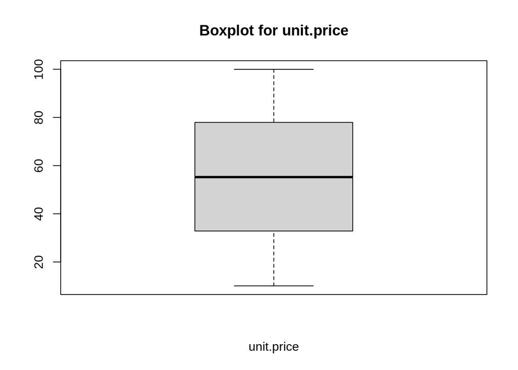

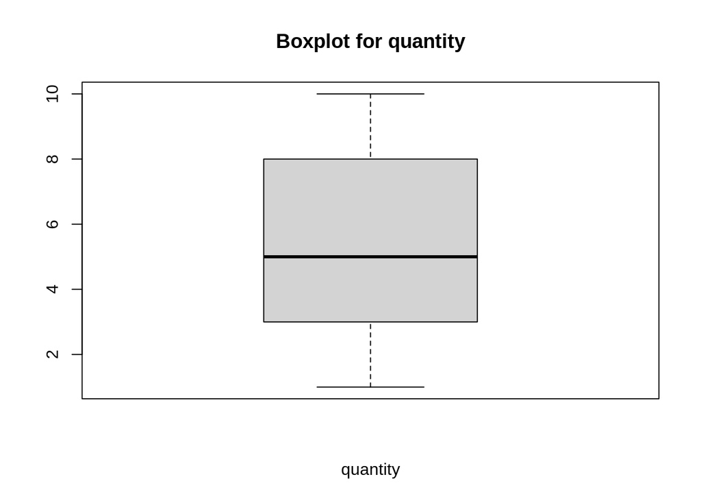

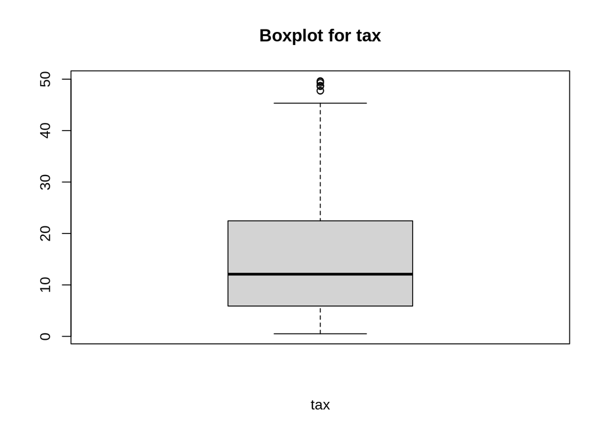

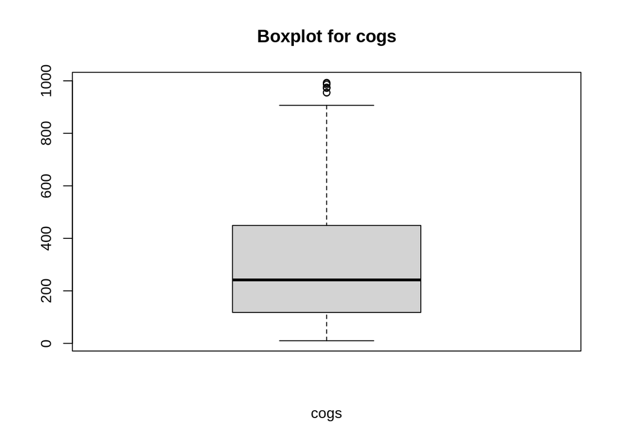

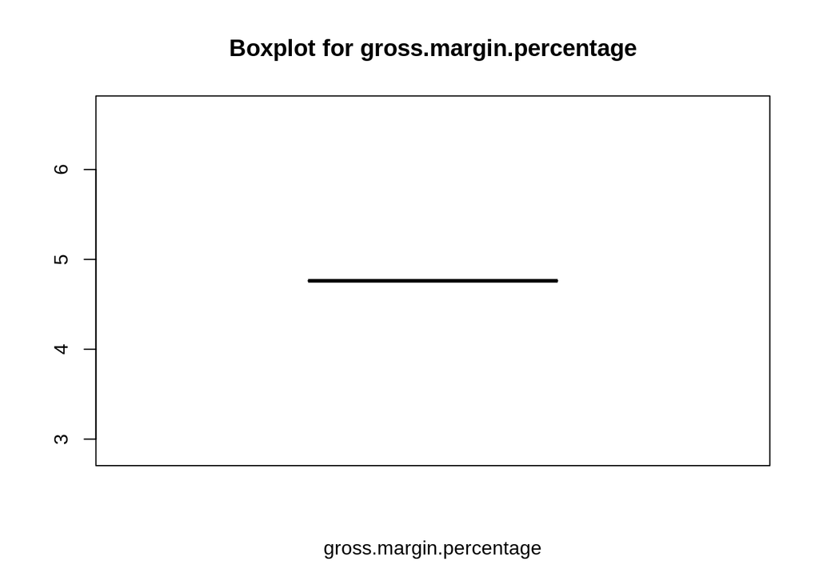

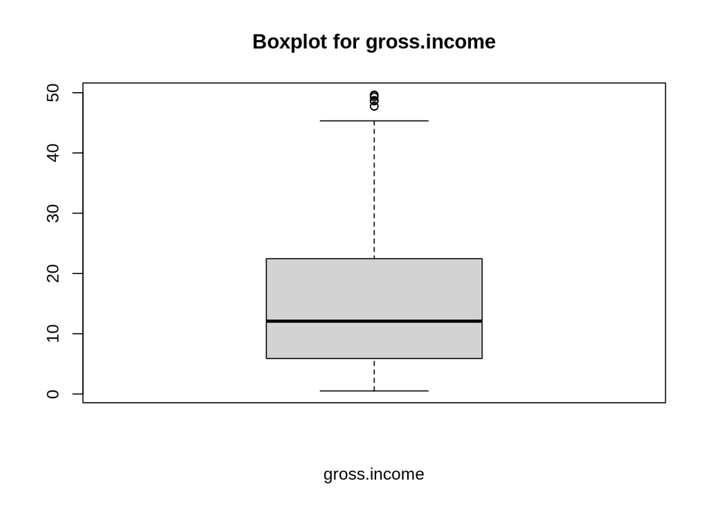

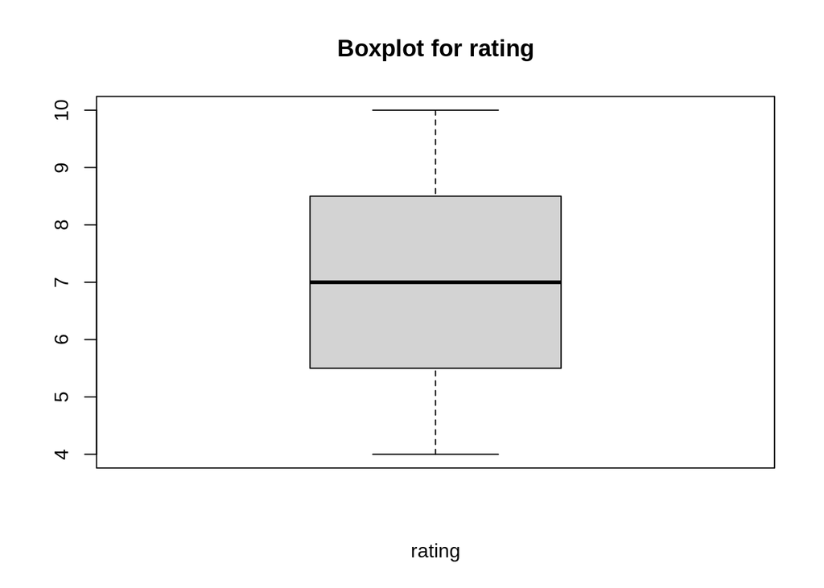

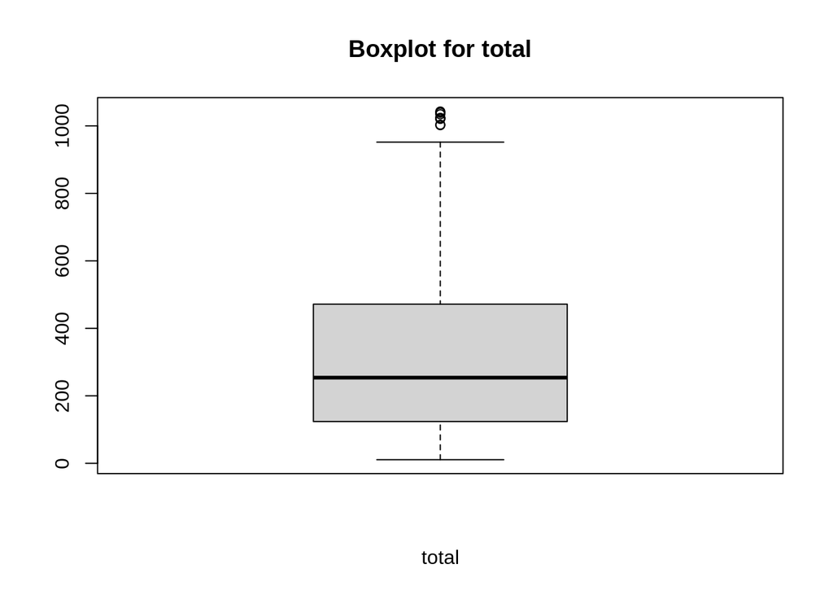

```r
# Check for outliers
num_col <- sales_new[, c(5,6,7,11,12,13,14,15)]
outlier_detection = function(x){
  for(i in colnames(x)){
    boxplot(sales_new[[i]], xlab=i, main=paste0("Boxplot for ",i))
  }
}

outlier_detection(num_col)
```

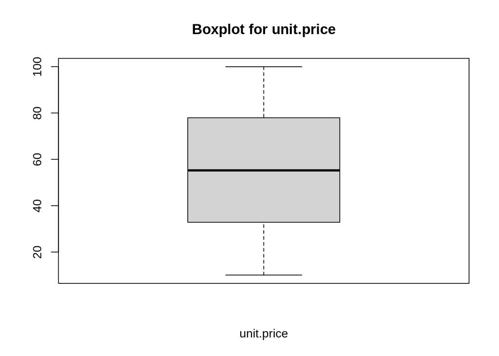

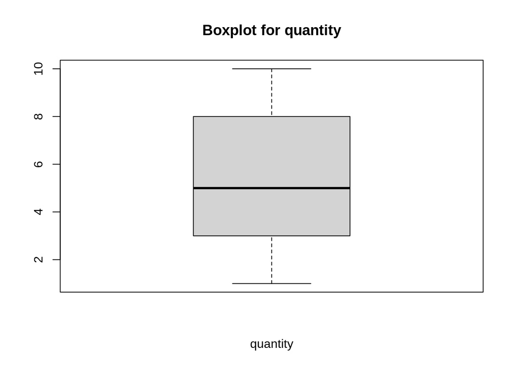

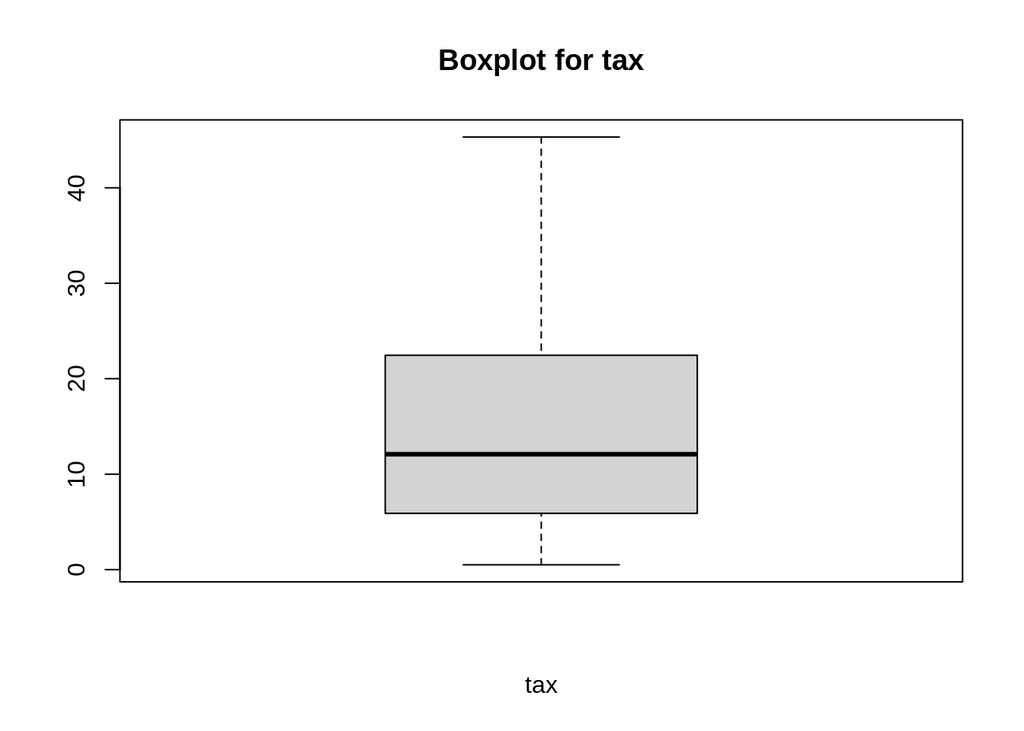

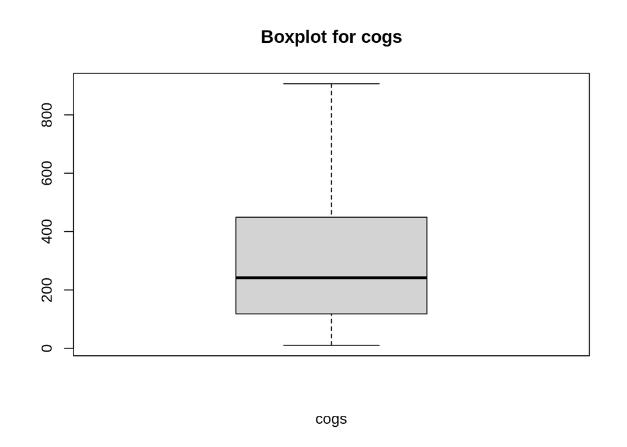

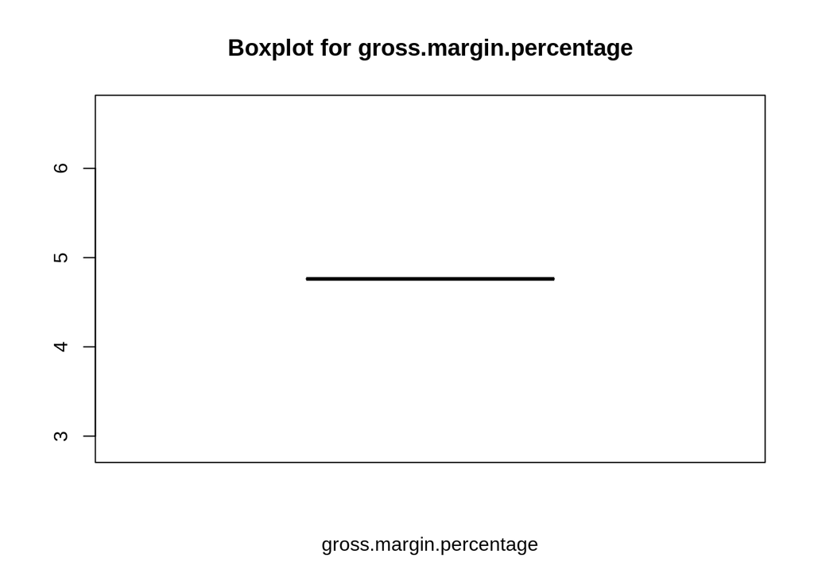

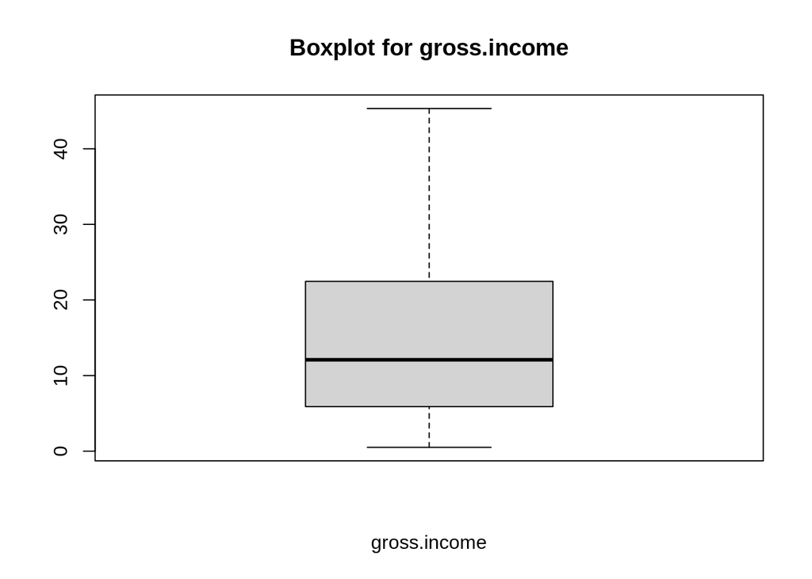

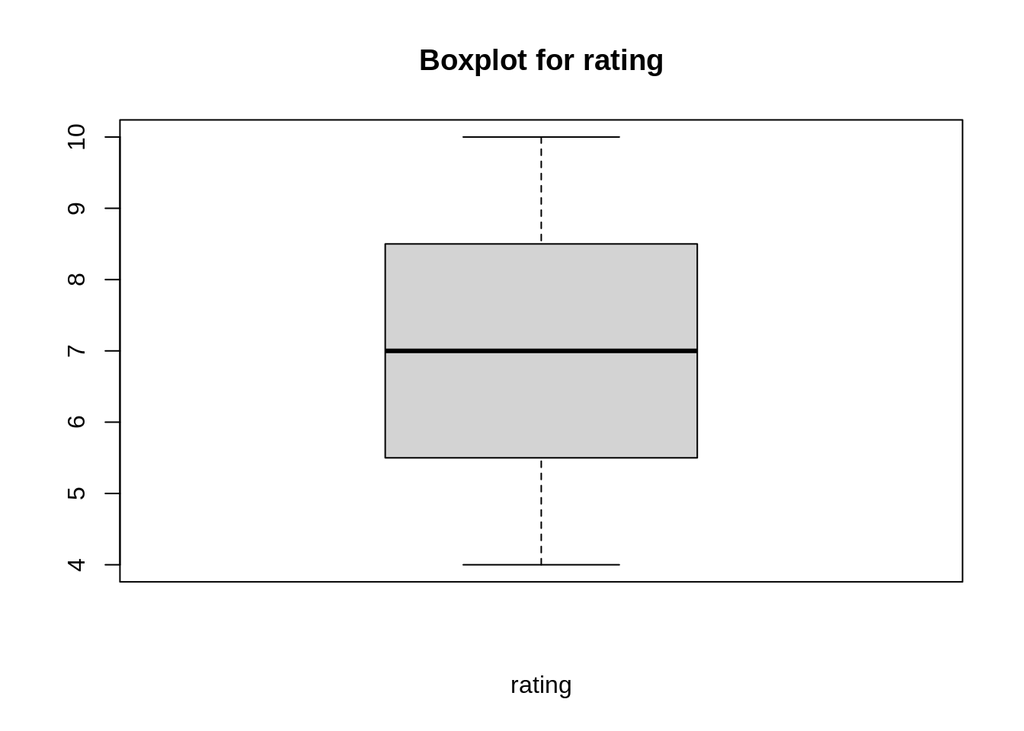

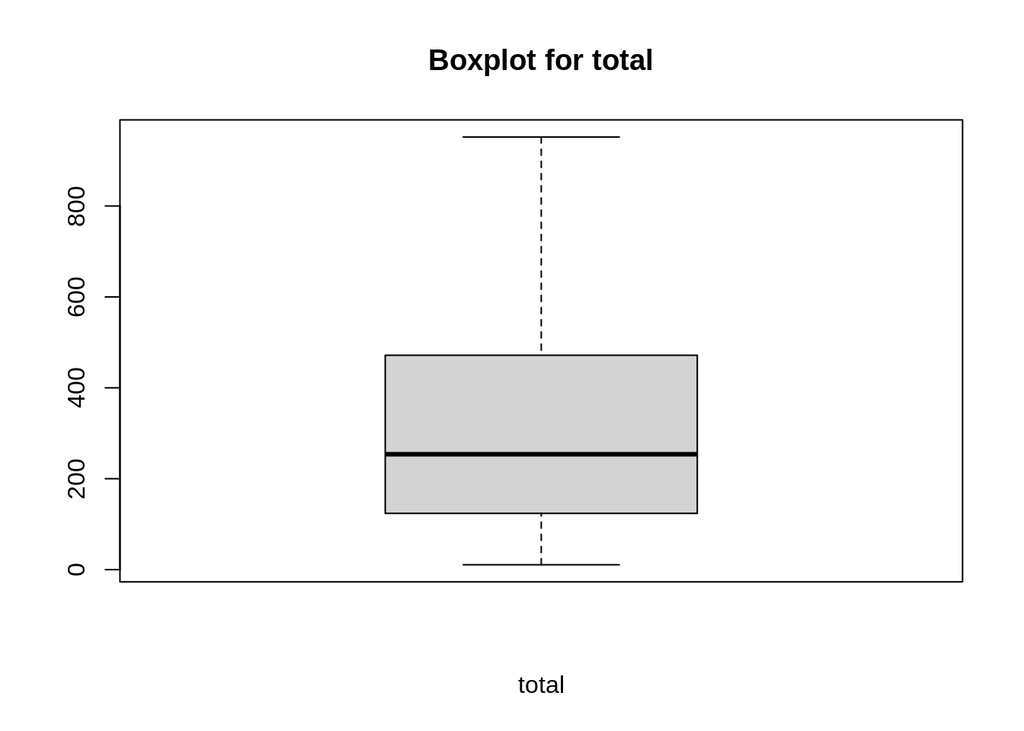

```r
# replace outliers with the 5th and 95th percentile
outlier_replace <- function(x){
   qnt <- quantile(x, probs=c(.25, .75), na.rm = T)
   caps <- quantile(x, probs=c(.05, .95), na.rm = T)
   H <- 1.5 * IQR(x, na.rm = T)
   x[x < (qnt[1] - H)] <- caps[1]
   x[x > (qnt[2] + H)] <- caps[2]
   return(x)
}


sales_new$tax <-outlier_replace(sales_new$tax)
sales_new$cogs <- outlier_replace(sales_new$cogs)
sales_new$gross.income <- outlier_replace(sales_new$gross.income)
sales_new$total <- outlier_replace(sales_new$total)

outlier_detection(num_col)
```

The Data had 1000 records and 16 columns

The Invoice.Id column was dropped because it was necessary for Analysis and all the columns were set to lower case for easier implementation There are no missing values or duplicated values in our data set

Categorical Variables were converted to Factors which were:-

1. Branch
2. Customer Type
3. Gender
4. Product Line
5. Payment

In the Numeric variables there were outliers in:-

1. Tax
2. Total
3. Cogs
4. Gross_Income

Where the outliers were replaced by the 5th and 95th percentile

# Perform Exploratory Data Analysis

## Univariate

### Categorical Variables

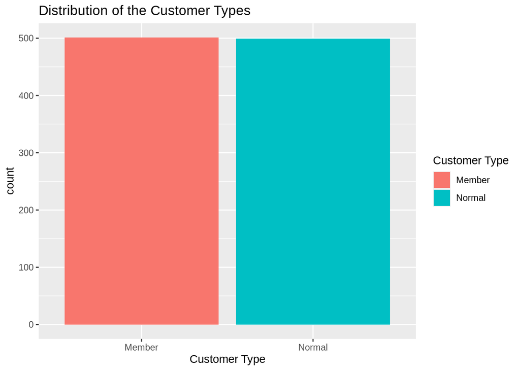

```r
library(ggplot2)

# Customer Type
customer_type <- ggplot(sales_new ,aes(x=customer.type , fill=customer.type)) + geom_bar() + labs(title = "Distribution of the Customer Types", x="Customer Type")
customer_type +scale_fill_discrete(name = "Customer Type")
```

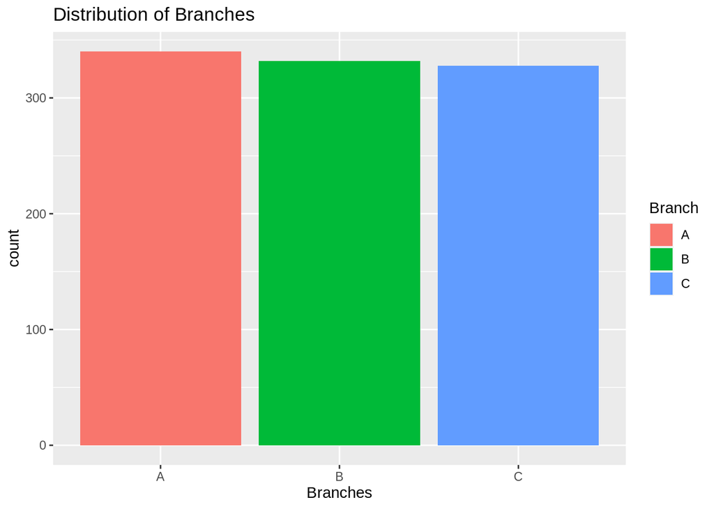

```r
# How many Branches we have
bran <- ggplot(sales_new, aes(x=branch, fill=branch)) + geom_bar()+labs(title = "Distribution of Branches", x="Branches")+scale_fill_discrete(name = "Branch")
bran
```

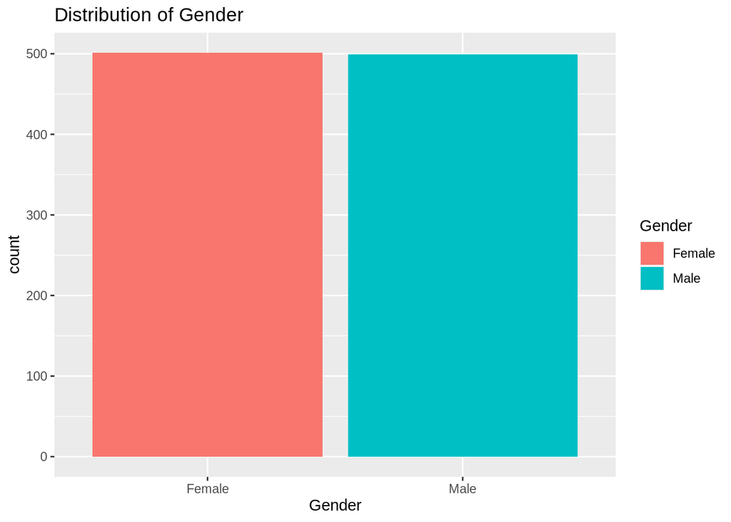

```r
# Gender Distribution
gender1 <- ggplot(sales_new, aes(x=gender, fill=gender)) + geom_bar()+labs(title = "Distribution of Gender", x="Gender")+scale_fill_discrete(name = "Gender")
gender1
```

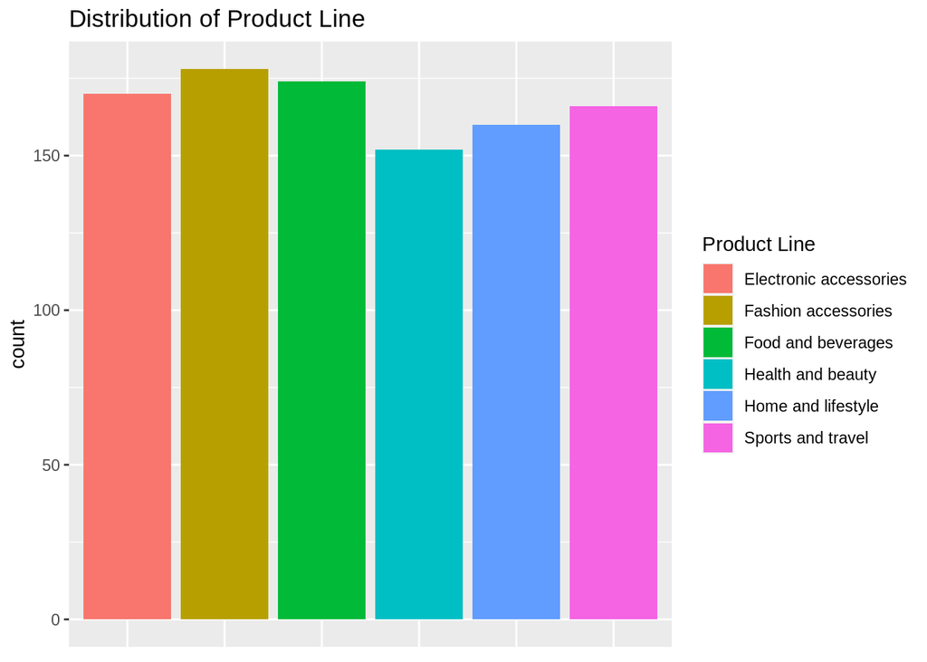

```r
# Types Product Line
product_line <- ggplot(sales_new,aes(x=product.line, fill=product.line))+ geom_bar()+ labs(title = "Distribution of Product Line", x="Product Line")+ scale_fill_discrete(name = "Product Line")
product_line + theme(axis.title.x=element_blank(),
        axis.text.x=element_blank(),
        axis.ticks.x=element_blank())
```

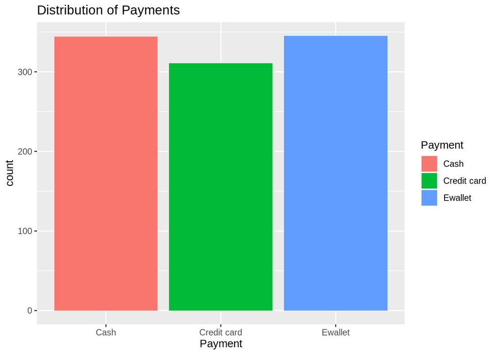

```r
# Types Payments
payment_meth <- ggplot(sales_new, aes(x=payment, fill=payment)) + geom_bar()+labs(title = "Distribution of Payments", x="Payment")+scale_fill_discrete(name = "Payment")
payment_meth
```

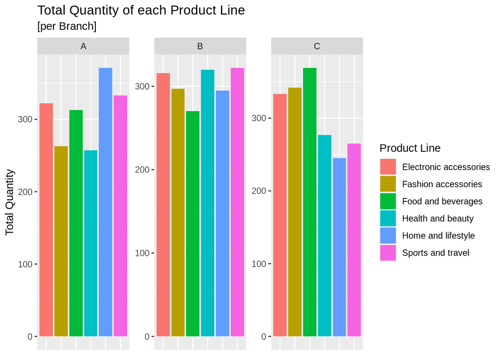

```r
# Which Product line was bought more in terms of quantity per branch
product_line1 <- ggplot(sales_new,aes(x=product.line,y=quantity,fill=product.line))+geom_bar(stat = "identity")+ facet_wrap(~branch, scales = "free") + labs(title = "Total Quantity of each Product Line", subtitle = "[per Branch]",x="Product Line", y="Total Quantity") + scale_fill_discrete(name = "Product Line") + theme(axis.title.x=element_blank(),
            axis.text.x=element_blank(),
            axis.ticks.x=element_blank())

product_line1
```

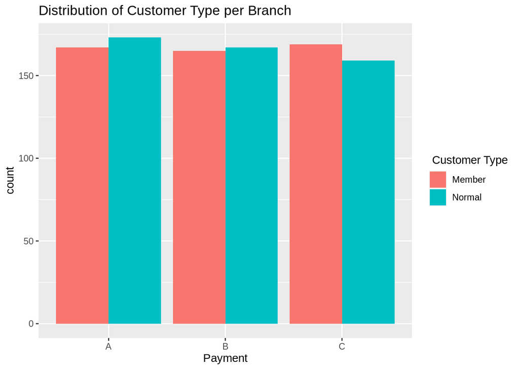

```r
# Customer Type per Branch
customer_type1 <- ggplot(sales_new, aes(x=branch, fill=customer.type)) + geom_bar(position = "dodge")+labs(title = "Distribution of Customer Type per Branch", x="Payment")+scale_fill_discrete(name = " Customer Type")
customer_type1
```

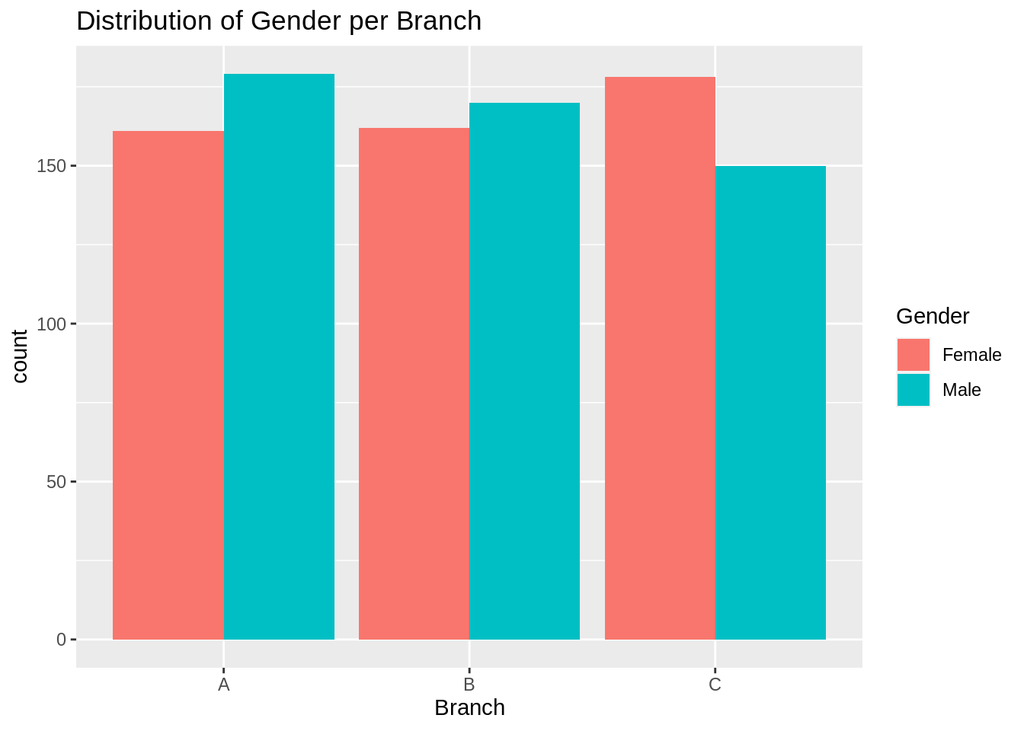

```r
# Gender per Branch
gender2 <- ggplot(sales_new, aes(x=branch, fill=gender)) + geom_bar(position = "dodge")+labs(title = "Distribution of Gender per Branch", x="Branch")+scale_fill_discrete(name = "Gender")
gender2
```

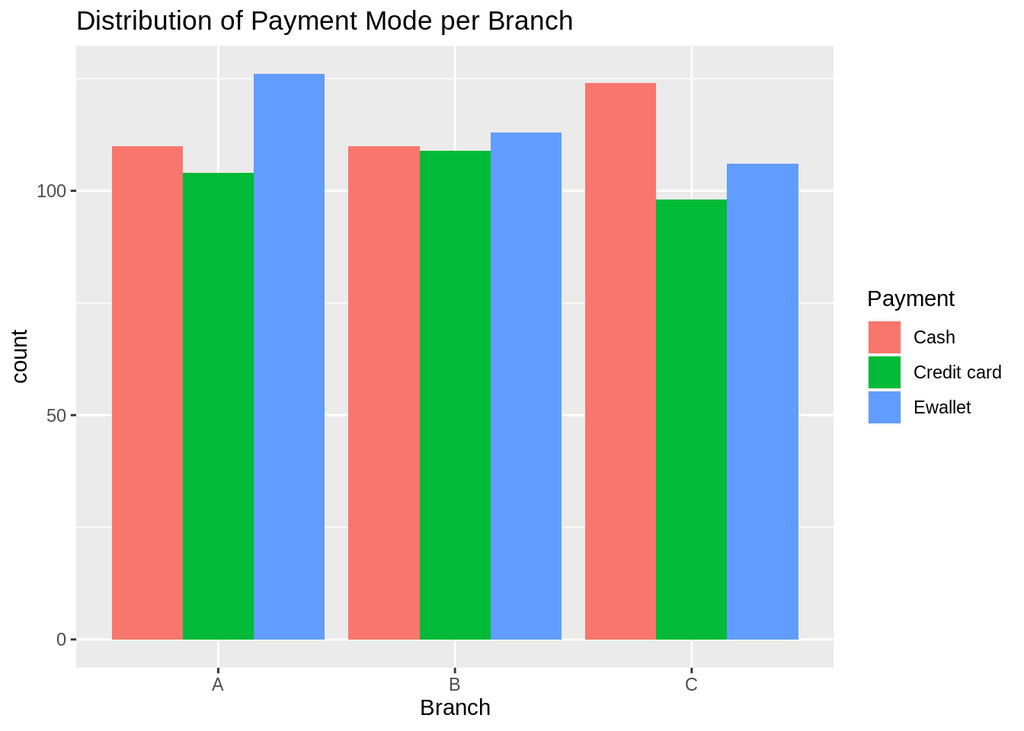

```r
# Mode of Payment per Branch
payment_meth1 <- ggplot(sales_new, aes(x=branch, fill=payment)) + geom_bar(position = "dodge")+labs(title = "Distribution of Payment Mode per Branch", x="Branch")+scale_fill_discrete(name = "Payment")
payment_meth1
```

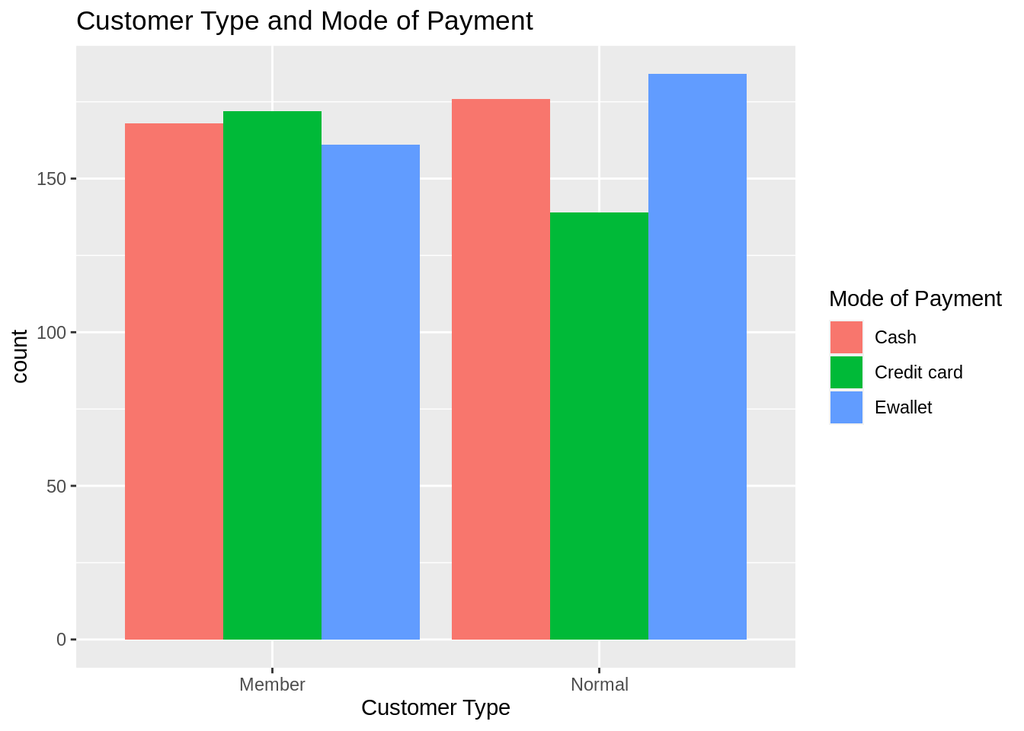

```r
# Customer Type and Mode of Payment
customer_type2 <- ggplot(sales_new, aes(x=customer.type, fill=payment)) + geom_bar(position = "dodge")+labs(title = "Customer Type and Mode of Payment", x="Customer Type")+scale_fill_discrete(name = "Mode of Payment")
customer_type2
```

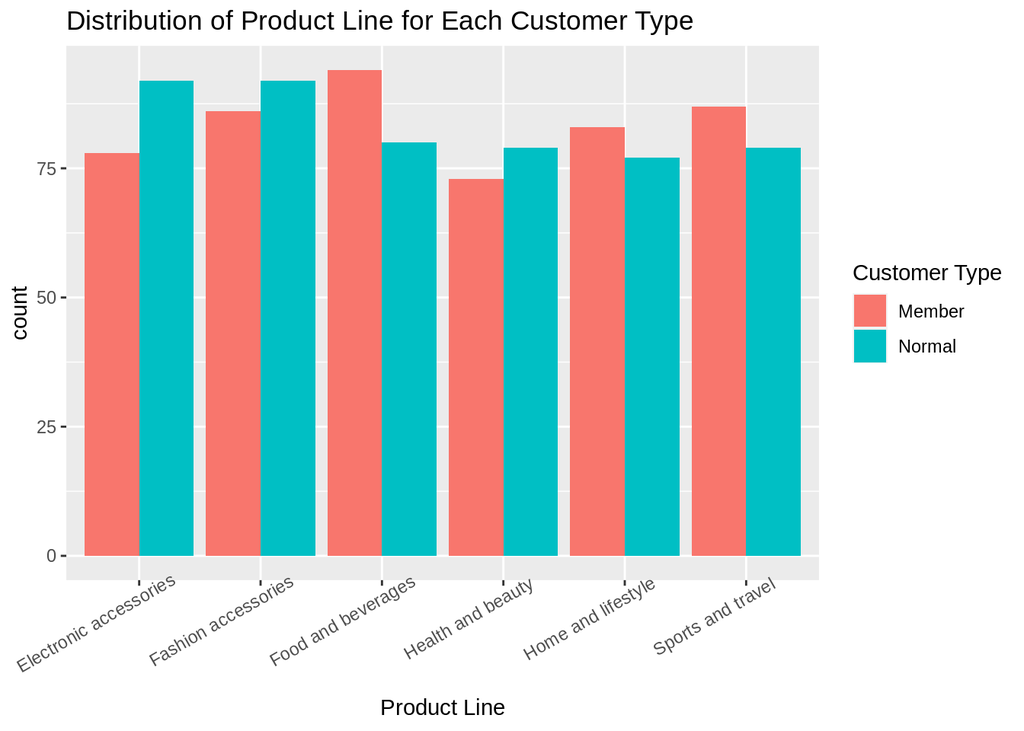

```r
# Customer Type and Product Line
product_line2 <- ggplot(sales_new, aes(x=product.line, fill=customer.type)) + geom_bar(position = "dodge")+labs(title = "Distribution of Product Line for Each Customer Type", x="Product Line")+scale_fill_discrete(name = "Customer Type")
product_line2 +theme(axis.text.x = element_text(angle = 30, hjust=0.8))
```

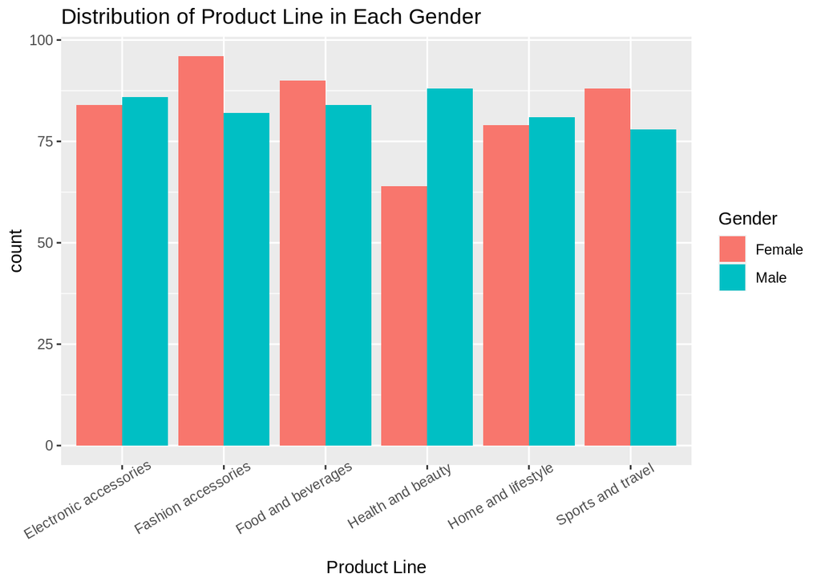

```r
# Product Line vs Gender
product_line3 <- ggplot(sales_new, aes(x=product.line, fill=gender)) + geom_bar(position = "dodge")+labs(title = "Distribution of Product Line in Each Gender", x="Product Line")+scale_fill_discrete(name = "Gender")
product_line3 +theme(axis.text.x = element_text(angle = 30, hjust=0.8))
```

### Numeric Variables

```r
library(Hmisc)
describe(num_col)
```

```
## num_col
##
##  8  Variables      1000  Observations
## --------------------------------------------------------------------------------
## unit.price
##        n  missing distinct     Info     Mean      Gmd      .05      .10
##     1000        0      943        1    55.67     30.6    15.28    19.31
##      .25      .50      .75      .90      .95
##    32.88    55.23    77.94    93.12    97.22
##
## lowest : 10.08 10.13 10.16 10.17 10.18, highest: 99.82 99.83 99.89 99.92 99.96
## --------------------------------------------------------------------------------
## quantity
##        n  missing distinct     Info     Mean      Gmd      .05      .10
##     1000        0       10     0.99     5.51     3.36        1        1
##      .25      .50      .75      .90      .95
##        3        5        8       10       10
##
## lowest :  1  2  3  4  5, highest:  6  7  8  9 10
##
## Value          1     2     3     4     5     6     7     8     9    10
## Frequency    112    91    90   109   102    98   102    85    92   119
## Proportion 0.112 0.091 0.090 0.109 0.102 0.098 0.102 0.085 0.092 0.119
## --------------------------------------------------------------------------------
## tax
##        n  missing distinct     Info     Mean      Gmd      .05      .10
##     1000        0      990        1    15.38    12.89    1.956    3.243
##      .25      .50      .75      .90      .95
##    5.925   12.088   22.445   34.234   39.166
##
## lowest :  0.5085  0.6045  0.6270  0.6390  0.6990
## highest: 48.6900 48.7500 49.2600 49.4900 49.6500
## --------------------------------------------------------------------------------
## cogs
##        n  missing distinct     Info     Mean      Gmd      .05      .10
##     1000        0      990        1    307.6    257.8    39.11    64.86
##      .25      .50      .75      .90      .95
##   118.50   241.76   448.91   684.68   783.33
##
## lowest :  10.17  12.09  12.54  12.78  13.98, highest: 973.80 975.00 985.20 989.80 993.00
```

[output cut: 20 more lines]

```
##     1000        0       61        1    6.973    1.985    4.295    4.500
##      .25      .50      .75      .90      .95
##    5.500    7.000    8.500    9.400    9.700
##
## lowest :  4.0  4.1  4.2  4.3  4.4, highest:  9.6  9.7  9.8  9.9 10.0
## --------------------------------------------------------------------------------
## total
##        n  missing distinct     Info     Mean      Gmd      .05      .10
##     1000        0      990        1      323    270.7    41.07    68.10
##      .25      .50      .75      .90      .95
##   124.42   253.85   471.35   718.91   822.50
##
## lowest :   10.6785   12.6945   13.1670   13.4190   14.6790
## highest: 1022.4900 1023.7500 1034.4600 1039.2900 1042.6500
## --------------------------------------------------------------------------------
```